# Sign Language Interpreter Aptitude

00 - Wrangling Set-up

Freya Watkins

University of Birmingham

31 August 2022

# Setup

## Load packages

```r
library(here) # file organisation & folder location
library(tidyverse) # data wrangling & plotting
library(naniar) # dealing with missing values
library(plotrix) # for calculating standard error
```

### R / package versions used

```r
R.Version()
```

```
## $platform
## [1] "x86_64-w64-mingw32"
##
## $arch
## [1] "x86_64"
##
## $os
## [1] "mingw32"
##
## $system
## [1] "x86_64, mingw32"
##
## $status
## [1] ""
##
## $major
## [1] "4"
##
## $minor
## [1] "0.5"
##
## $year
## [1] "2021"
##
## $month
## [1] "03"
##
## $day
## [1] "31"
##
## $`svn rev`
## [1] "80133"
##
## $language
## [1] "R"
##
## $version.string
## [1] "R version 4.0.5 (2021-03-31)"
##
## $nickname
## [1] "Shake and Throw"
```

```r
packageVersion('here')
```

```
## [1] '1.0.1'
```

```r
packageVersion('tidyverse')
```

```
## [1] '1.3.1'
```

```r
packageVersion('naniar')
```

```
## [1] '0.6.1'
```

```r
packageVersion('psych')
```

```
## [1] '2.1.6'
```

## Read in data

```r
# here::here() # check we're working in the right place
apt <- read_csv(here("data", "apt-data.csv"))
apt <- as_tibble(apt)
```

## Convert variables

```r
spec(apt) # check current variable classes
apt <- apt %>% mutate(across(c(self_rating:grade_terp), as.numeric)) # convert DVs to numeric
apt <- apt %>% mutate(across(c(session:selection, continuation, L1_bsl), as.factor)) # convert IVs to factor
```

# Look at data

```r
head(apt) # look at first 6 rows
```

```
## # A tibble: 6 x 44
##   session group ppt   selection selected contin~1 conti~2 L1_bsl self_~3 bsl_y~4
##   <fct>   <fct> <fct> <fct>        <dbl> <fct>      <dbl> <fct>    <dbl>   <dbl>
## 1 1       first S70   selected         1 withdrew       1 0            4      10
## 2 1       first S41   selected         1 withdrew       0 0            1       0
## 3 1       first S63   selected         1 withdrew       0 0            2       2
## 4 1       first S90   selected         1 withdrew       0 0            1       0
## 5 1       first S60   selected         1 withdrew       0 0            1       0
## 6 1       first S96   selected         1 continu~       1 1            5      14
## # ... with 34 more variables: nback_lett <dbl>, nback_spat <dbl>,
## #   nback_comb <dbl>, corsi_bspan <dbl>, corsi_score <dbl>, corsi_corr <dbl>,
## #   corsi_mspan <dbl>, kirk_ceil <dbl>, kirk_raw <dbl>, kirk_acc <dbl>,
## #   kbit_ceil <dbl>, kbit_raw <dbl>, kbit_acc <dbl>, dspan_mem <dbl>,
## #   dspan_corr <dbl>, dspan_time <dbl>, mr2d_acc <dbl>, mr2d_rt <dbl>,
## #   mr3d_acc <dbl>, mr3d_rt <dbl>, bis_tot <dbl>, bis_att <dbl>, bis_mot <dbl>,
## #   bis_nplan <dbl>, mlat_raw <dbl>, mlat_acc <dbl>, summ <dbl>, ...
```

```r
tail(apt) # look at final 6 rows
```

```
## # A tibble: 6 x 44
##   session group ppt   selection selected contin~1 conti~2 L1_bsl self_~3 bsl_y~4
##   <fct>   <fct> <fct> <fct>        <dbl> <fct>      <dbl> <fct>    <dbl>   <dbl>
## 1 1       first S50   rejected         0 na             0 0            4      NA
## 2 1       first S91   rejected         0 na             0 0            3      NA
## 3 1       first S94   rejected         0 na             0 0            2      NA
## 4 1       first S62   rejected         0 na             0 0            1      NA
## 5 1       first S46   rejected         0 na             0 0            1      NA
## 6 1       first S76   rejected         0 na             0 0            1      NA
## # ... with 34 more variables: nback_lett <dbl>, nback_spat <dbl>,
## #   nback_comb <dbl>, corsi_bspan <dbl>, corsi_score <dbl>, corsi_corr <dbl>,
## #   corsi_mspan <dbl>, kirk_ceil <dbl>, kirk_raw <dbl>, kirk_acc <dbl>,
## #   kbit_ceil <dbl>, kbit_raw <dbl>, kbit_acc <dbl>, dspan_mem <dbl>,
## #   dspan_corr <dbl>, dspan_time <dbl>, mr2d_acc <dbl>, mr2d_rt <dbl>,
## #   mr3d_acc <dbl>, mr3d_rt <dbl>, bis_tot <dbl>, bis_att <dbl>, bis_mot <dbl>,
## #   bis_nplan <dbl>, mlat_raw <dbl>, mlat_acc <dbl>, summ <dbl>, ...
```

```r
names(apt) # list all the column/variable names
```

```
##  [1] "session"      "group"        "ppt"          "selection"    "selected"
##  [6] "continuation" "continue"     "L1_bsl"       "self_rating"  "bsl_years"
## [11] "nback_lett"   "nback_spat"   "nback_comb"   "corsi_bspan"  "corsi_score"
## [16] "corsi_corr"   "corsi_mspan"  "kirk_ceil"    "kirk_raw"     "kirk_acc"
## [21] "kbit_ceil"    "kbit_raw"     "kbit_acc"     "dspan_mem"    "dspan_corr"
## [26] "dspan_time"   "mr2d_acc"     "mr2d_rt"      "mr3d_acc"     "mr3d_rt"
## [31] "bis_tot"      "bis_att"      "bis_mot"      "bis_nplan"    "mlat_raw"
## [36] "mlat_acc"     "summ"         "copy_sign"    "bsl_srt"      "town_map"
## [41] "terp_b2e"     "terp_e2b"     "grade_bsl"    "grade_terp"
```

```r
summary(apt) # summarise the variables
```

```
##  session    group         ppt         selection      selected
##  1:52    first :63   S03    :  4   rejected: 19   Min.   :0.0000
##  2:33    second:88   S07    :  4   selected:132   1st Qu.:1.0000
##  3:33                S10    :  4                  Median :1.0000
##  4:33                S13    :  4                  Mean   :0.8742
##                      S16    :  4                  3rd Qu.:1.0000
##                      S17    :  4                  Max.   :1.0000
##                      (Other):127
##      continuation    continue      L1_bsl   self_rating      bsl_years
##  continuing:84    Min.   :0.0000   0:139   Min.   :1.000   Min.   : 0.000
##  na        :19    1st Qu.:0.0000   1: 12   1st Qu.:1.000   1st Qu.: 0.000
##  withdrew  :48    Median :1.0000           Median :2.000   Median : 1.000
##                   Mean   :0.5563           Mean   :2.384   Mean   : 3.788
##                   3rd Qu.:1.0000           3rd Qu.:3.000   3rd Qu.: 4.000
##                   Max.   :1.0000           Max.   :6.000   Max.   :18.000
##                                                            NA's   :19
##    nback_lett       nback_spat       nback_comb      corsi_bspan
##  Min.   :0.5900   Min.   :0.4800   Min.   :0.5500   Min.   :5.000
##  1st Qu.:0.6950   1st Qu.:0.7000   1st Qu.:0.7100   1st Qu.:6.000
##  Median :0.7200   Median :0.7300   Median :0.7200   Median :6.000
##  Mean   :0.7164   Mean   :0.7192   Mean   :0.7173   Mean   :6.165
##  3rd Qu.:0.7500   3rd Qu.:0.7500   3rd Qu.:0.7500   3rd Qu.:6.000
##  Max.   :0.7900   Max.   :0.7900   Max.   :0.7800   Max.   :9.000
##  NA's   :67       NA's   :67       NA's   :67       NA's   :66
##   corsi_score       corsi_corr      corsi_mspan      kirk_ceil
##  Min.   : 30.00   Min.   : 6.000   Min.   :4.000   Min.   :19.0
##  1st Qu.: 48.00   1st Qu.: 8.000   1st Qu.:5.000   1st Qu.:34.5
##  Median : 54.00   Median : 9.000   Median :5.500   Median :39.0
##  Mean   : 56.41   Mean   : 8.976   Mean   :5.488   Mean   :37.6
##  3rd Qu.: 60.00   3rd Qu.:10.000   3rd Qu.:6.000   3rd Qu.:42.0
##  Max.   :126.00   Max.   :14.000   Max.   :8.000   Max.   :42.0
##  NA's   :66       NA's   :66       NA's   :66      NA's   :76
##     kirk_raw        kirk_acc        kbit_ceil        kbit_raw
##  Min.   :14.00   Min.   :0.4800   Min.   :20.00   Min.   :16.00
##  1st Qu.:28.00   1st Qu.:0.7450   1st Qu.:41.00   1st Qu.:37.00
##  Median :31.00   Median :0.8100   Median :43.00   Median :40.00
##  Mean   :30.09   Mean   :0.8003   Mean   :41.88   Mean   :38.53
##  3rd Qu.:33.00   3rd Qu.:0.8600   3rd Qu.:45.00   3rd Qu.:41.00
##  Max.   :39.00   Max.   :0.9700   Max.   :46.00   Max.   :46.00
##  NA's   :76      NA's   :76       NA's   :76      NA's   :76
```

[output cut: 25 more lines]

```
##  Min.   :0.2900   Min.   :60.00   Min.   :61.50   Min.   : 7.00   Min.   : NA
##  1st Qu.:0.7075   1st Qu.:75.00   1st Qu.:69.88   1st Qu.:11.00   1st Qu.: NA
##  Median :0.8550   Median :85.00   Median :74.25   Median :13.00   Median : NA
##  Mean   :0.7891   Mean   :80.28   Mean   :76.36   Mean   :14.13   Mean   :NaN
##  3rd Qu.:0.9475   3rd Qu.:87.50   3rd Qu.:84.25   3rd Qu.:17.00   3rd Qu.: NA
##  Max.   :1.0000   Max.   :90.00   Max.   :89.50   Max.   :24.00   Max.   : NA
##  NA's   :129      NA's   :142     NA's   :135     NA's   :136     NA's   :151
##     terp_b2e        terp_e2b       grade_bsl       grade_terp
##  Min.   :58.60   Min.   :44.50   Min.   :34.00   Min.   :44.00
##  1st Qu.:62.77   1st Qu.:54.10   1st Qu.:57.25   1st Qu.:51.00
##  Median :64.50   Median :61.80   Median :62.50   Median :59.50
##  Mean   :64.95   Mean   :62.33   Mean   :62.83   Mean   :60.32
##  3rd Qu.:67.03   3rd Qu.:67.00   3rd Qu.:70.00   3rd Qu.:67.75
##  Max.   :72.60   Max.   :83.00   Max.   :85.00   Max.   :84.00
##  NA's   :143     NA's   :142     NA's   :93      NA's   :117
```

## Overview of variables

**session** - testing session (1-4)  
**group** - whether participants belonged to the first two cohorts or second two cohorts (first, second)  
**ppt** - randomized participant ID codes to ensure anonymity (between S01-S99)  
**selection** - whether participants were selected or rejected for the degree or not (selected, rejected)  
**selected** - as above, in numeric form (1=selected, 0=rejected)  
**continuation** - whether participants continued with the degree at the time of analysis (continuing, withdrew)  
**continue** - as above, in numeric form (1=continuing, 0=withdrew)  
**L1_bsl** - whether ppts were L1 signers of BSL or not (1=L1 BSL, 0=L2 BSL)  
**self_rating** - initial BSL self-rating on likert scale (1-7) at session 1  
**nback_lett** - accuracy on the letter matching task of the dual N-Back (% as decimal 0-1)  
**nback_spat** - accuracy on the spatial matching task of the dual N-Back (% as decimal 0-1)  
**nback_comb** - combined accuracy on the dual N-Back task (average of nback_lett & nback_spat)  
**corsi_bspan** - block span on the Corsi blocks task  
**corsi_score** - score on the Corsi blocks task  
**corsi_corr** - total correct trials on the Corsi blocks task  
**corsi_mspan** - memory span on the Corsi blocks task (in length of sequence)  
**kirk_ceil** - ceiling item on the Kirklees reading test (max 42)  
**kirk_raw** - raw score on the Kirklees reading test (max 42)  
**kirk_acc** - accuracy on the Kirklees reading test (% as decimal 0-1)  
**kbit_ceil** - ceiling item on the KBIT-2 matrices task (max 46)  
**kbit_raw** - raw score on the KBIT-2 matrices task (max 46)  
**kbit_acc** - accuracy on the KBIT-2 matrices task (% as decimal 0-1)  
**dspan_mem** - memory span on the Digit Span task (in digits)  
**dspan_corr** - accuracy on the Digit Span task (% as decimal 0-1)  
**dspan_time** - time taken on the Digit Span (in minutes, seconds as decimals)  
**mr2d_acc** - accuracy on the 2D Mental Rotation task (% as decimal 0-1)  
**mr2d_rt** - average reaction time of correct trials on the 2D Mental Rotation task (ms)  
**mr2d_sats** - speed-accuracy trade-off score for the 2D Mental Rotation task (calculated below)  
**mr3d_acc** - accuracy on the 3D Mental Rotation task (% as decimal 0-1)  
**mr3d_rt** - average reaction time of correct trials on the 3D Mental Rotation task (ms)  
**mr3d_sats** - speed-accuracy trade-off score for the 3D Mental Rotation task (calculated below)  
**bis_tot** - total score on the Baratt Impulsiveness Scale (min 30, max 120)  
**bis_att** - attention sub-score on the Baratt Impulsiveness Scale  
**bis_mot** - motor sub-score on the Baratt Impulsiveness Scale  
**bis_nplan** - non-planning sub-score on the Baratt Impulsiveness Scale  
**mlat_raw** - raw score on the MLAT Number Learning task (max 43)  
**mlat_acc** - accuracy on the MLAT Number Learning task (% as decimal 0-1)  
**summ** - score on the summarising task (0-100, graded like UK university assignment)  
**copy_sign** - score on the copy-sign task (0-96 points max)  
**bsl_srt** - score on the BSL Sentence Reproduction Test (0-44)  
**town_map** - score on the BSL Town Map task (not yet coded)  
**terp_b2e** - score on the BSL to English interpreting task (0-100, UK grading system)  
**terp_e2b** - score on the English to BSL interpreting task (0-100, UK grading system)  
**grade_bsl** - BSL grade (average of all modules in that year, 0-100 UK grading system)  
**grade_terp** - interpreting grade (average of all modules in that year, 0-100 UK grading system)

Let’s check some facts about the dataset:

```r
levels(apt$session)
```

```
## [1] "1" "2" "3" "4"
```

There were four testing sessions.

```r
unique(apt$ppt)
```

```
##  [1] S70 S41 S63 S90 S60 S96 S65 S71 S33 S25 S19 S77 S98 S31 S52 S39 S84 S17 S03
## [20] S13 S07 S89 S16 S97 S85 S68 S10 S73 S49 S42 S18 S92 S79 S99 S56 S28 S66 S72
## [39] S64 S54 S15 S95 S20 S24 S81 S29 S50 S91 S94 S62 S46 S76
## 52 Levels: S03 S07 S10 S13 S15 S16 S17 S18 S19 S20 S24 S25 S28 S29 S31 ... S99
```

There were 52 participants in total.

```r
apt %>% filter(selected==1) %>% nrow() / 4
```

```
## [1] 33
```

```r
apt %>% filter(selected==0) %>% nrow()
```

```
## [1] 19
```

There were 33 participants who were selected for the degree program and 19 who were rejected after interview.

## Summarise missingness

Due to high attrition and participants only completing specific tasks at each testing session, there is a lot of missing data. Let’s try to summarise and visualise it.

First let’s list all predictor/outcome variables in decreasing order of missing data (%)

```r
apt %>% select(-session:-ppt) %>%
  naniar::miss_var_summary()
```

```
## # A tibble: 41 x 3
##    variable  n_miss pct_miss
##    <chr>      <int>    <dbl>
##  1 town_map     151    100
##  2 terp_b2e     143     94.7
##  3 summ         142     94.0
##  4 terp_e2b     142     94.0
##  5 bsl_srt      136     90.1
##  6 copy_sign    135     89.4
##  7 mlat_raw     129     85.4
##  8 mlat_acc     129     85.4
##  9 bis_tot      127     84.1
## 10 bis_att      127     84.1
## # ... with 31 more rows
```

The data is in long format, so some tasks appear to have a much higher degree of ‘missingness’ than is really the case, because we did not test all tasks at all sessions. E.g. the interpreting tasks were only carried out at the final testing session. We also include rows for ALL selected participants at ALL sessions for extra clarity, even though many dropped out of the degree and were not re-tested. Participants rejected after interview also only completed the initial set of tasks, so their data for other tasks is not really ‘missing’ either, but counted here.

Next let’s make the data in wide format, i.e. separate columns for each session per task

```r
apt_wide <- apt %>%
  tidyr::pivot_wider(names_from = session,
                     values_from = c(nback_lett:grade_terp)) # create wide data format
```

List all predictor/outcome variables in decreasing order of missing data (%) but this time per session

```r
naniar::miss_var_summary(apt_wide)
```

```
## # A tibble: 145 x 3
##    variable     n_miss pct_miss
##    <chr>         <int>    <dbl>
##  1 kirk_ceil_4      52      100
##  2 kirk_raw_4       52      100
##  3 kirk_acc_4       52      100
##  4 kbit_ceil_4      52      100
##  5 kbit_raw_4       52      100
##  6 kbit_acc_4       52      100
##  7 dspan_mem_2      52      100
##  8 dspan_corr_2     52      100
##  9 dspan_time_2     52      100
## 10 bis_tot_1        52      100
## # ... with 135 more rows
```

Again, most of the variables where missingness is 100% is because this task was not tested at this session. Town Map data is missing because it has not been coded etc.

Now let’s visualise the missingness:

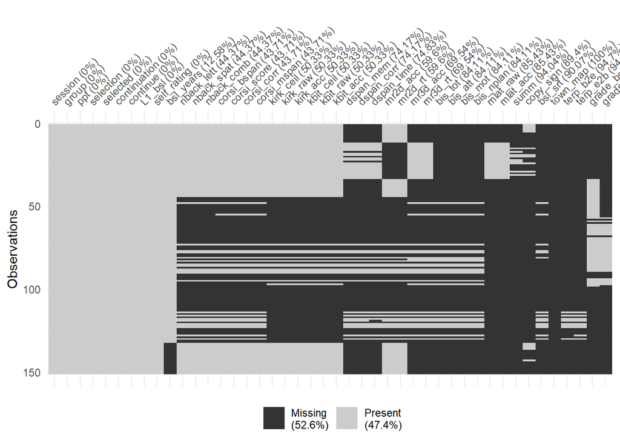

```r
vis_miss(apt) # visualise missingness of long-format data
```

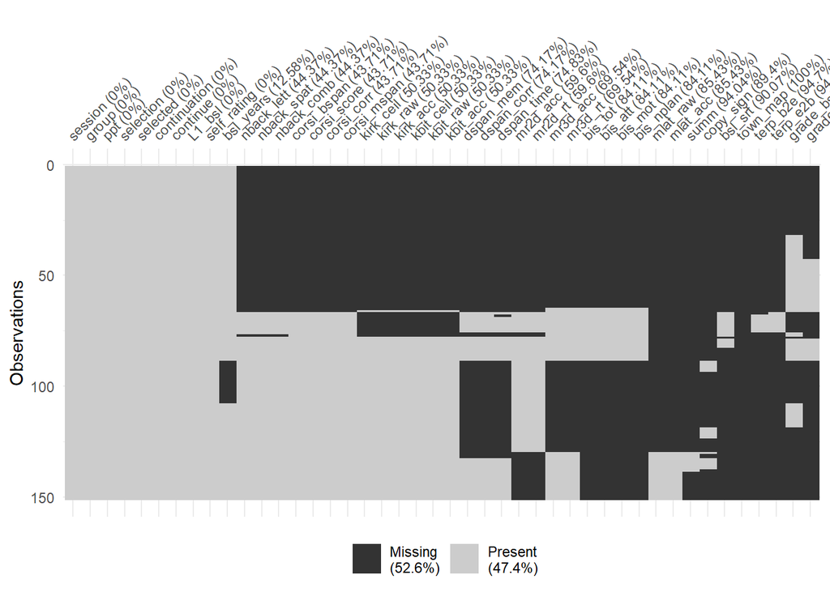

```r
vis_miss(apt, cluster = TRUE) # arrange rows according to missingness
```

Finally show the missingness on a row by row basis i.e. by participant & session

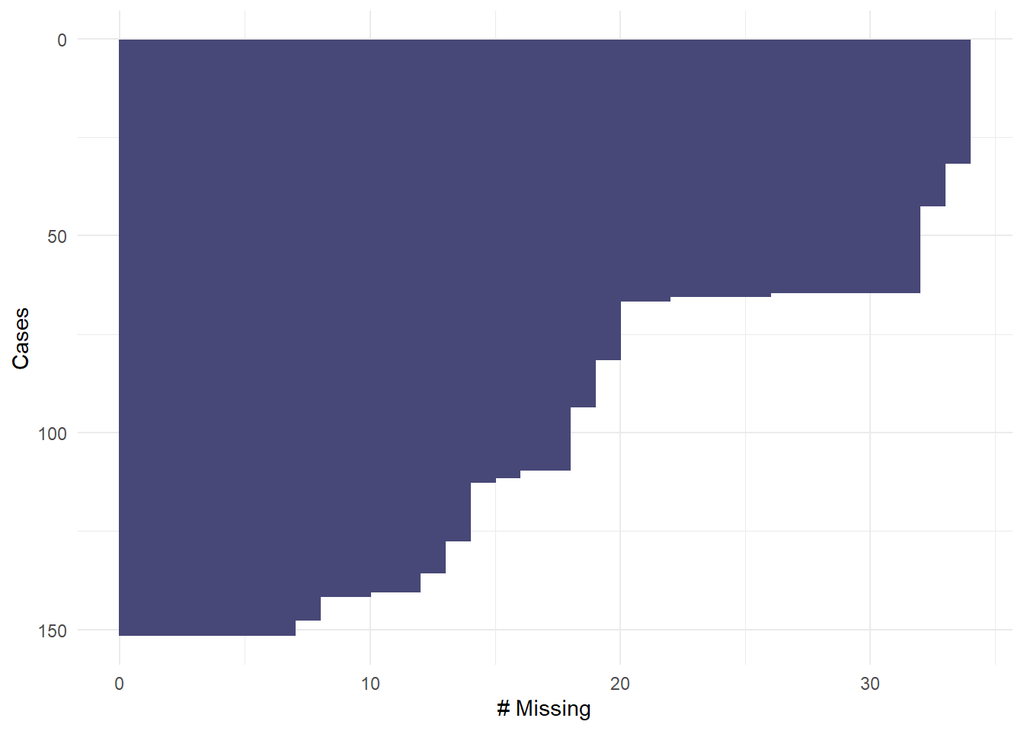

```r
gg_miss_case(apt)
```

Not all of the missingness is a problem, for some variables we did not plan to test on all participants

## Calculate mental rotation SATS

We will use the Balanced Integration Score by Liesefeld et al to calculate a speed-accuracy trade-off score for the mental rotation task data.

```r
# Create speed accuracy trade-off score function (Balanced Integration Score; BIS)
# (Liesefeld, Fu, & Zimmer, 2015; Liesefeld & Janczyk, in press)

# create the BIS function
BIS <- function(data) {
  n <- length(data$group)   # sample size to correct var()-function result (which uses n-1)
  srt <- sqrt( ((n-1)/n) * var(data$mean_rt_c) )  # sample standard deviation across all rts
  spc <- sqrt( ((n-1)/n) * var(data$pc) ) # sample standard deviation across all rts
  mrt <- mean(data$mean_rt_c)                     # mean across all rts
  mpc <- mean(data$pc)                            # mean across all pcs
  zrt <- (data$mean_rt_c-mrt)/srt                 # standardized rts
  zpc <- (data$pc-mpc)/spc                        # z-standardized pcs
  data$bis <- zpc - zrt                           # Balanced Integration Score

  return(data)             # return data.frame with added variable 'bis'
}

# Extract relevant columns for 2D Mental Rotation data
mean_rt_c <- apt$mr2d_rt
pc <- apt$mr2d_acc
group <- apt$session
ppt <- apt$ppt
data <- data.frame(group,ppt,mean_rt_c,pc) # put relevant cols in 'data' df
data <- data %>% drop_na() # remove NAs

# create speed-accuracy trade off score (calling it SATS here, to avoid confusion with having two BIS acronyms in the dataset), rename variables back to fit with original tibble
( SATS_mr2d <- BIS(data) %>% dplyr::rename(c(session = group,
                                             mr2d_acc = pc,
                                             mr2d_rt = mean_rt_c,
                                             mr2d_sats = bis)) )
```

```
##    session ppt mr2d_rt mr2d_acc    mr2d_sats
## 1        1 S70    4052     0.73 -1.868008801
## 2        1 S41    2580     0.91  0.746554860
## 3        1 S63    3752     0.93  0.076940054
## 4        1 S90    2965     0.93  0.642709045
## 5        1 S60    2507     0.95  1.144890243
## 6        1 S96    3057     0.88  0.144250646
## 7        1 S65    2376     0.91  0.893209084
## 8        1 S71    1934     0.91  1.210959902
## 9        1 S33    8256     0.98 -2.728634944
## 10       1 S25    2430     0.94  1.113780980
## 11       1 S19    3696     0.95  0.290126164
## 12       2 S70    3193     0.88  0.046481163
## 13       2 S41    2036     0.97  1.656417054
## 14       2 S63    2808     0.89  0.409719110
```

[output cut: 47 more lines]

```r
# join back to apt tibble
apt <- full_join(apt, SATS_mr2d) %>% relocate(mr2d_sats, .after = mr2d_rt )

# Same again for 3D Mental Rotation task
mean_rt_c <- apt$mr3d_rt
pc <- apt$mr3d_acc
data <- data.frame(group,ppt,mean_rt_c,pc)
data <- data %>% drop_na() # remove NAs

# create SATS; rename variables back to fit with original tibble
( SATS_mr3d <- BIS(data) %>% dplyr::rename(c(session = group,
                                             mr3d_acc = pc,
                                             mr3d_rt = mean_rt_c,
                                             mr3d_sats = bis)) )
```

```
##    session ppt mr3d_rt mr3d_acc   mr3d_sats
## 1        1 S77    2417     0.92  1.79716452
## 2        1 S98    4285     0.59 -2.95710679
## 3        1 S31    4085     0.58 -2.70122950
## 4        1 S52    3253     0.86  0.15911936
## 5        1 S39    2442     0.90  1.64651425
## 6        1 S84    2891     0.70 -0.17014981
## 7        1 S17    4121     0.40 -3.76250661
## 8        1 S03    3527     0.75 -0.88220600
## 9        1 S13    3170     0.60 -1.16342552
## 10       1 S07    3258     0.15 -3.81350111
## 11       1 S89    3862     0.51 -2.74456025
## 12       1 S16    3398     0.68 -1.07204512
## 13       1 S97    2656     0.88  1.20128864
## 14       1 S85    3832     0.46 -2.97701546
```

[output cut: 32 more lines]

```r
# join back to apt tibble
apt <- full_join(apt, SATS_mr3d) %>% relocate(mr3d_sats, .after = mr3d_rt )
```

Rename levels of Session for tables/plotting:

```r
apt$session <- plyr::revalue(apt$session, c("1" = "pre-degree",
                                            "2" = "1st year",
                                            "3" = "2nd year",
                                            "4" = "3rd year"))
```

# Export wrangled data

Export the wrangled data file for use in other analysis scripts as an R data object:

```r
saveRDS(apt, here("data", "apt-data.rds"))
```

This concludes our initial exploration of the data and wrangling, in preparation for the three analysis scripts.